# CoVaR in R: A Quick Tutorial

Jorge A. Chan-Lau

International Monetary Fund and Risk Management Institute, National University of Singapore

Macrofinancial Linkages, Systemic Risk, and Macroprudential Policy; Washington, D.C., November 6-8, 2017

# Objective

This tutorial teaches how to estimate the $CoVaR$ and $\Delta CoVaR$ measures using `R` and Roger Koenker’s `quantreg` package.

# Getting started

## Setting up the working directory

Start by setting up a working directory in your computer. For this tutorial, the directory has already been set up for you, and it is named `C:/ChanLau/CoVaR`.

Start RStudio. In the IDE, go to the console window. There, change the woking directory to the one containing the data files using the command `setwd()`. The argument for the command should be the name of the desired working directory.

```r
setwd("D:/Work/IET MPP Course/Workshops/CoVaR")

# The directory in the D: hard drive is the working directory in my personal computer.
# set your directory to "C:/ChanLau/CoVaR"
```

To confirm the working directory is the desired one, type `getwd()` and execute the command pressing the `Enter` key. Afterwards, clean the memory using the command `rm(list=ls())`:

```r
getwd()
```

```
## [1] "D:/Work/IET MPP Course/Workshops/CoVaR"
```

```r
rm(list=ls())
```

## Installing and loading packages

There are numerous mathematical and statistical methods in `R` available through external packages (or libraries) stored in the `CRAN` repository. The tutorial uses four packages: `quantreg` to estimate quantile regression models; `lubridate` and `dplyr` to manipulate data; and `ggplot2` to produce charts.

Installing a package requires downloading it first. When there is access to the Internet, the following command checks whether the package is installed, and downloads it if not:

```r
if(!require(quantreg)){install.packages("quantreg")}
if(!require(dplyr)){install.packages("dplyr")}
if(!require(ggplot2)){install.packages("ggplot2")}
if(!require(lubridate)){install.packages("lubridate")}
```

To make the libraries accessible the `R` programs, run the `library()` command:

```r
library(quantreg)
library(dplyr)
library(ggplot2)
library(lubridate)
```

The libraries and functions are ready to be used.

## Reading and preparing the data files

Check the data files we have for this exercise in the *Files* window in the bottom left pane of your `RStudio` IDE (Figure 1)

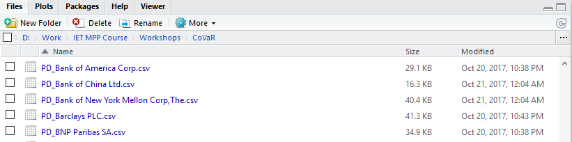

Files in CoVaR tutorial directory

The `PD_XYZ.csv` file contains time series data for the probabilities of default (PDs) of bank `XYZ` for different horizons: 1, 3, 6, 12, 24, 36, and 60 months. The PD data was downloaded from the Credit Research Initiative (CRI) at the National University of Singapore on October 20,2017. The PDs were calculated using the model calibration of June 10, 2017, and using data available on September 29, 2017. The sample data ends on March 31, 2017. Different firms have different start dates. This data is freely available to those in the academic and policy making community.

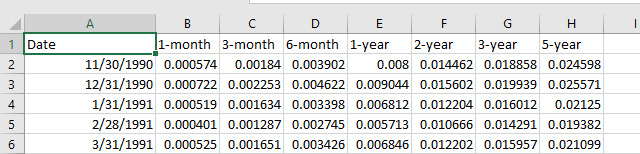

Data structure of a `PD_XYZ.csv` file

Use the function `read.csv()`, included in the base package `utils`, to read the `.csv` data files. Let’s read the data for two large U.S. banks, Bank of New York, and Wells Fargo, into two data frames, `BNY` and `WFG` respectively:

```r
fileName = "PD_Bank of New York Mellon Corp,The.csv"
BNY  = read.csv(fileName, header = TRUE, sep =",")
fileName = "PD_Wells Fargo & Co.csv"
WFG  = read.csv(fileName, header = TRUE, sep =",")
rm(fileName)
```

Check the `Global Environment` window in the IDE to confirm the data frames are there,

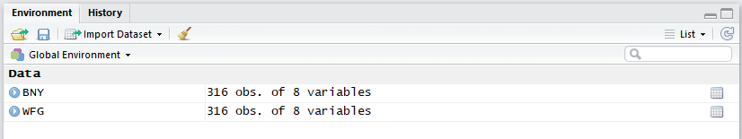

Global environment `PD_XYZ.csv` file

and click on any of them to check the data format:

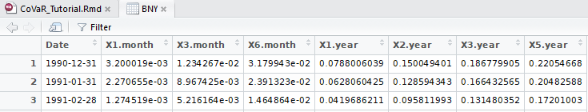

`BNY` data frame

The column names, as read from the original `cvs` files, are ugly. Let’s change them:

```r
nice_names = c('1mo', '3mo', '6mo', '1yr', '2yr','3yr','5yr')
colnames(BNY)[2:8] = nice_names
colnames(WFG)[2:8] = nice_names
rm(nice_names)
```

We will estimate the $CoVaR$ and $\Delta CoVaR$ measures for the 1-yr PDs. Let’s create an appropriate data frame. First, we check if the sample dates in the `BNY` and `WFG` data frames are the same:

```r
identical(BNY$Date,WFG$Date)
```

```
## [1] TRUE
```

since this is the case, we proceed to create the data frame `the.data`. Note the use of the command `ymd`, from the `lubridate` package, to transform the alpha numerical values in `Dates` to a format the graphics commands `plot()` or `ggplot()` can use:

```r
#logit transformation of the PDs

logBNY = log(BNY$`1yr`)/(1-log(BNY$`1yr`))
logWFG = log(WFG$`1yr`)/(1-log(WFG$`1yr`))

# create the data frame for QR estimation

the.data = data.frame(ymd(BNY$Date),BNY$`1yr`, WFG$`1yr`, logBNY, logWFG)
colnames(the.data) = c("Dates", "BNY", "WFG", "logBNY", "logWFG")
```

Plot the time series and check whether there are some data anomalies:

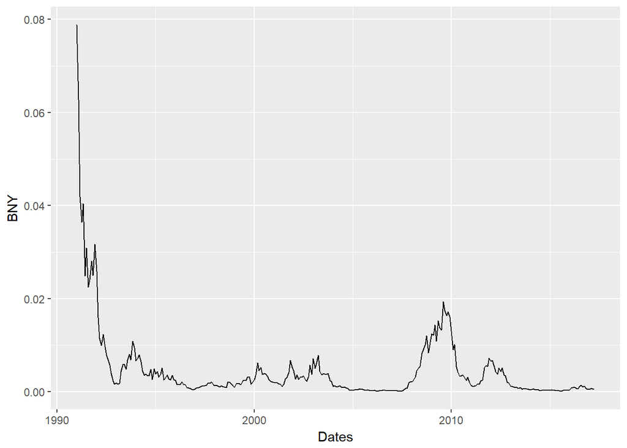

```r
ggplot(the.data, aes(x=Dates, y=BNY)) + geom_line()
```

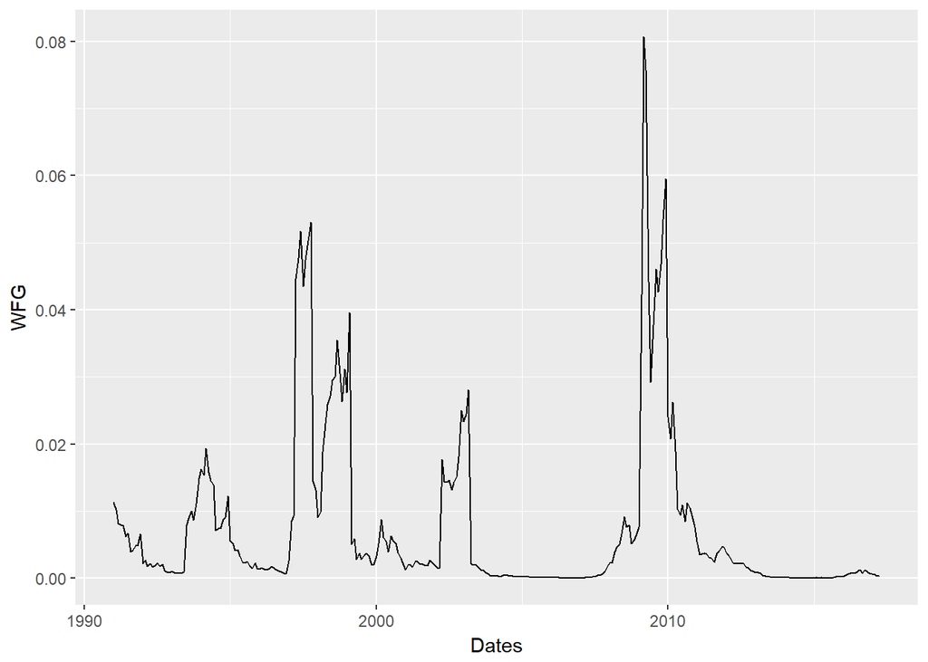

```r
ggplot(the.data, aes(x=Dates, y=WFG)) + geom_line()
```

# $CoVaR$ and $\Delta CoVaR$ Estimation

```r
# Estimate QR for tau = 0.99

QR99 = rq(logWFG~logBNY,tau = 0.99, data=the.data)  # QR, 99 percentile
```

To visualize how the QR performs agains the data, plot a scatter plot of the PDs for both banks, and overlay the OLS line (black dashed line), as well as the QR lines for different percentiles (red for the 99 percentile, blue for the 50 percentile, or median regression, and shades of gray for other percentiles):

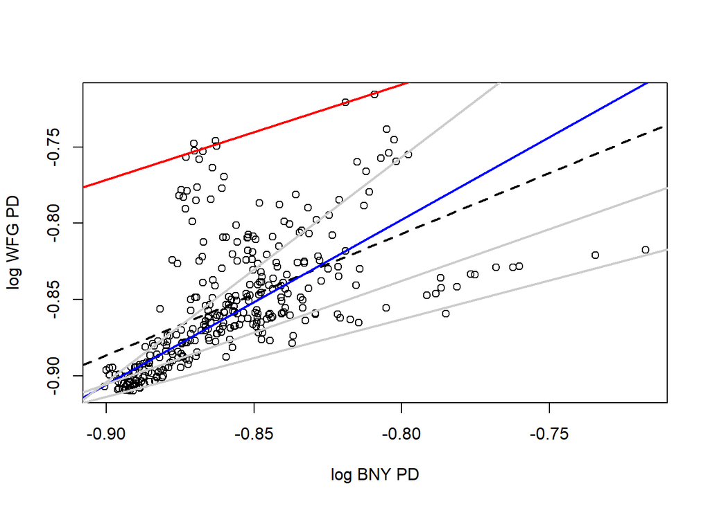

```r
# Plot the data against OLS and QRs for different percentiles

plot(the.data$logBNY, the.data$logWFG, cex = 0.25, type = "n", xlab="log BNY PD",
     ylab = "log WFG PD")
points(the.data$logBNY,the.data$logWFG,cex =1.00, col = "black")
abline(lm(the.data$logWFG~the.data$logBNY), col = "black", lty=2, lwd =2 )      # OLS regressino
abline(rq(logWFG~logBNY,tau = 0.50, data=the.data), col = "blue", lwd = 2)     # Median regression
abline(rq(logWFG~logBNY,tau = 0.01, data=the.data), col = "grey80", lwd = 2)   #  1 percentile QR
abline(rq(logWFG~logBNY,tau = 0.25, data=the.data), col = "grey80", lwd = 2)   # 25 percentile QR
abline(rq(logWFG~logBNY,tau = 0.75, data=the.data), col = "grey80", lwd = 2)   # 75 percentile QR
abline(rq(logWFG~logBNY,tau = 0.99, data=the.data), col = "red", lwd = 2)      # 99 percentile QR
```

```r
# Find the sample quantiles corresponding to the 50 and 99 percentiles

BNY50 = quantile(logBNY, 0.50)
BNY99 = quantile(logBNY, 0.99)

# Get the coefficient for the logit PD

betaBNY = QR99$coefficients[2]

# Calculate the Delta CoVaR

DeltaCoVaR_BNY = betaBNY*(BNY99-BNY50)
DeltaCoVaR_BNY
```

```
##     logBNY
## 0.06095791
```

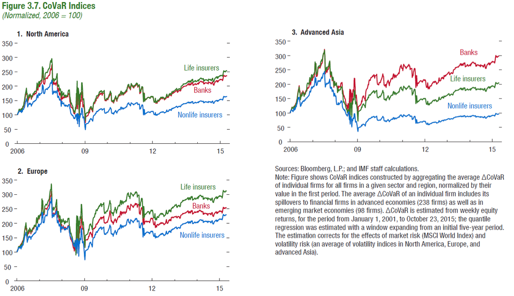

CoVaR Indices, GFSR, April 2016

### References

- Chan-Lau, J.A. 2017. [Quantile Regressions in R: a Quick Tutorial](https://htmlpreview.github.io/?https://github.com/jchanlauimf/CoVaR-Demo/blob/master/html/QRTutorial.html)
- Koenker, R. 2005. [*Quantile Regression*](https://www.amazon.com/Quantile-Regression-Econometric-Society-Monographs/dp/0521608279) Cambridge University Press.
- Koenker, R. 2015. [Package ‘quantreg’](https://cran.r-project.org/web/packages/quantreg/quantreg.pdf). CRAN repository.
- Koenker, R. 2015. [Quantile Regression in R: a Vignette](https://cran.r-project.org/web/packages/quantreg/vignettes/rq.pdf). CRAN repository.